# ExamPrepFinalized

## 22 Problem 2

Linear FIR filtering with 3 coefficients and $l=3$.

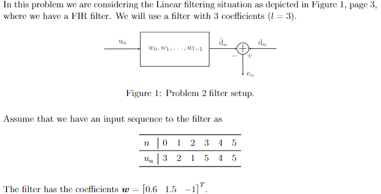

### 22 2.1

Determine the output of the filter at $n=3$

#### Answer

We are asked to find $\hat{d}_{n=3}$. We use eq. (4.41) which states:

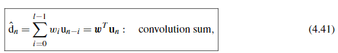

$$\hat{d}_{n=3} = \sum^{3-1}_{i=0}w_iu_{3-i} = w_0u_3+w_1u_2+w_2u_1 =$$

```python
l = 3
n = 3
w = np.array([0.6, 1.5, -1])
u_n = np.array([3,2,1,5,4,5])
d_hat_n = w.T @ np.array([u_n[n], u_n[n-1], u_n[n-2]])
print(f"d_hat_3 = {d_hat_n.item()}")
```

```
d_hat_3 = 2.5
```

### 22 2.2

Learning-based setup to recover $s_n$. $u_n=s_n+x_n$, where $x_n,s_n \sim AR(1)$. Additionally $v_n=s_n+\eta_n$ where follows a white-noise sequence ie. $\eta_n \sim \mathcal{N}(0, \sigma^2)$

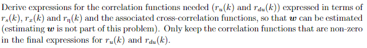

#### Answer

$$\begin{align*} r_u(k)&=\mathbb{E}[u_nu_{n-k}] = \mathbb{E}[(s_n+x_n)(s_{n-k}+x_{n-k})] \\ &=\mathbb{E}[s_ns_{n-k}+x_nx_{n-k}+s_nx_{n-k}+x_ns_{n-k}] \\ &=\mathbb{E}[s_ns_{n-k}]+\mathbb{E}[x_nx_{n-k}]+\mathbb{E}[s_nx_{n-k}]+\mathbb{E}[x_ns_{n-k}] \\ &=r_s(k)+r_x(k)+r_{sx}(k)+r_{xs}(k) \\ &=r_s(k)+r_x(k) \end{align*}$$

Since AR processes are generated with white noise they are assumed uncorrelated, ie. $r_{xs}=r_{sx}=0$. Now, here the problem is a bit weirdly put, but $d_n=v_n=s_n+\eta_n$ is what we should use...

$$\begin{align*} r_{du}(k)&=\mathbb{E}[d_nu_{n-k}] = \mathbb{E}[(s_n+\eta_n)(s_{n-k}+x_{n-k})] \\ &=\mathbb{E}[s_ns_{n-k}+s_nx_{n-k}+\eta_n s_{n-k}+\eta_n x_{n-k}] \\ &=r_s(k) \end{align*}$$ Here, since $\eta_n$ is a white-noise sequence (zero mean $\mathbb{E}[\eta_n]=0$) and $s_n$ and $x_n$ are $AR(1)$-processes, they all vanish, respectively, leaving us with $r_s(k)$

### 22 2.3

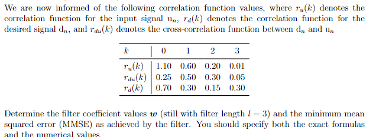

#### Answer

To determine the filter coefficient (with $l=3$) and the MMSE we need to consult the book, particularly p.136 where:

$$R_u=\Sigma_u \\ \Sigma_u w = p \Leftrightarrow w = \Sigma_u^{-1} p = R_u^{-1} p$$

The MMSE can be found in ch. 4.2.1 p. 123 eq. (4.9), where we simply choose the one applicable to our case. In this case $\theta$ is not known, hence we have to use the first option listed here:

$$J(\theta)=\sigma_y^2-p^T\Sigma^{-1}_x p=\sigma^2_y\theta_*^T\Sigma_x\theta_*=\sigma_y^2-p^T\theta_*$$ where $\Sigma_x=\Sigma_u$, as $u$ is our input and $y=d$ is our output, where we recall that the first option $r_d(0)=\sigma_d^2$ of its cross-correlation matrix $\Sigma_d$.

```python
#### First part
r_u0 = 1.10; r_u1 = 0.6; r_u2 = 0.20; r_u3 = 0.01
# recall it is populated by r(0) -> r(l-1) square matrix, symmetric
R_u = np.array([[r_u0, r_u1, r_u2],
                [r_u1, r_u0, r_u1],
                [r_u2, r_u1, r_u0]])
r_du0 = 0.25; r_du1 = 0.5; r_du2 = 0.3; r_du3 = 0.05
p = np.array([[r_du0], [r_du1], [r_du2]]) # p is a column vector
w = np.linalg.inv(R_u) @ p
print(f"w = \n{w}\n")

#### Second part
r_d0 = 0.70
J = r_d0 - p.T @ np.linalg.inv(R_u) @ p
print(f"MMSE = {J.item()}")
```

```
w =
[[-0.02]
 [ 0.45]
 [ 0.03]]

MMSE = 0.47132237871674487
```

### 22 2.4

Learning system of filter with LMS. Stepsize, filter weights.

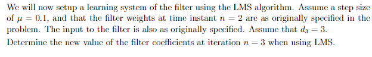

#### Answer

If we assume $n=2$ filter weights, then we have the same $u$, $w$ and $n$ as given in the original problem statement.

LMS is given by the algorithm:

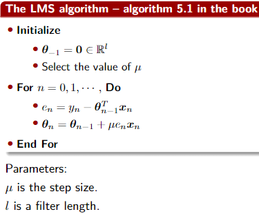

so for $n=3$, which means $x_n = u_3 = [u_3, u_{3-1}, u_{3-2}] = [5~~1~~2]^T$ (see (4.41)), $\mu=0.1$ and $y_n = d_3=3$. $$ e_3= y_3-\theta_{3-1}^T x_3 = d_3 - w^T_{3-1}[5~~1~~2]^T \\ \theta_3 = \theta_{3-1}+\mu e_3 x_3 = w^T_{3-1} + \mu e_3 u_3 $$

```python
w = np.array([0.6, 1.5, -1]) # column vector
u_3 = np.array([5,1,2]) # column vector
d_3 = 3
mu = 0.1

e_3 = d_3 - w.T @ u_3
theta_3 = w + mu * e_3 * u_3
print(f"e_3 = {e_3}")
print(f"theta_3 = {theta_3}")
```

```
e_3 = 0.5
theta_3 = [ 0.85  1.55 -0.9 ]
```

### 22 2.5

RLS with $l=2$. Time varying component is adequately modeled. Determine steady-state excess MSE using RLS for $\beta=0.95$. Also find $\beta$ that gives the lowest steady-state excess MSE

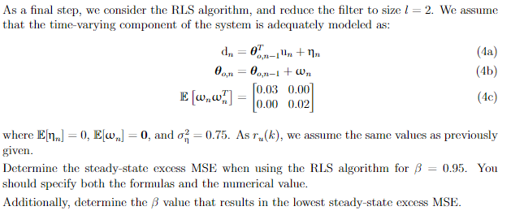

#### Answer

This looks oddly like ch. 6.8 "Steady-state performance of the RLS". Table 6.1 on p 276 describes the steady-state excess MSE for LMS, RLS and APA (and NLMS).

$$ J_{exc}^{RLS} \simeq \frac{1}{2}(1-\beta)\sigma_\eta^2 l + \frac{1}{2}(1-\beta)^{-1}\text{trace}\{\Sigma_\omega\Sigma_x\} $$ Where the input $x$ is now $u$, hence we need to use $\Sigma_u$.

The optimal $\beta$ can be found using equation on page 277:

$$ \beta_{opt} = 1 - \sqrt{\frac{\text{trace}\{\Sigma_\omega \Sigma_x\}}{\sigma_\eta^2\cdot l}} $$

```python
beta = 0.95
l = 2
Sigma_omega = np.array([[0.03, 0.00],
                        [0.00, 0.02]])
Sigma_u = np.array([[r_u0, r_u1],
                    [r_u1, r_u0]]) # Since l = 2, (r(0), r(l-1))
print(f"Sigma_u = \n{Sigma_u}")
sigma2_eta = 0.75

J_rls_excess = 1/2 * (1-beta) * sigma2_eta * l + 1/2 * (1-beta)**(-1) * np.trace(Sigma_omega@Sigma_u)
print(f"J_RLS_excess = {round(J_rls_excess,2)}")

beta_optimal = 1 - np.sqrt(  np.trace(Sigma_omega@Sigma_u) / (sigma2_eta * l)  )
print(f"Optimal Beta = {round(beta_optimal,2)}")

# Double checking this indeed gives a lower excess MSE:
J_opt =  1/2 * (1-beta_optimal) * sigma2_eta * l + 1/2 * (1-beta_optimal)**(-1) * np.trace(Sigma_omega@Sigma_u)
print(f"\nChecking if new J_exc is lower with new beta:\nJ_opt = {round(J_opt,2)}")
```

```
Sigma_u =
[[1.1 0.6]
 [0.6 1.1]]
J_RLS_excess = 0.59
Optimal Beta = 0.81

Checking if new J_exc is lower with new beta:
J_opt = 0.29
```

## 22 Problem 3

Concerns ICA using Mutual Information

### 22 3.1

Suppose we are in a room with 4 microphones and 4 sources, which are assumed stationary. The assumption of instantaneous mixing is satisfied.

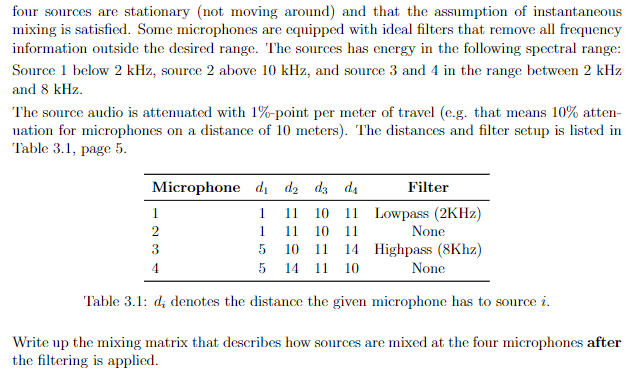

#### Answer

The mixing matrix $A$ can be found by careful inspection of the above picture and information. Note, it is *after* the filtering is applied. So, first we inspect every microphone and what source $d_n$ for $n\in \{1, 2, 3, 4\}$ is "recorded" by the microphone after passing through the filter. We note the following: $$ d_1 < 2kHz \\ d_2 > 10kHz \\ 2kHz < d_3~\text{and}~d_4 < 8kHz $$

**Microphone 1**:

- $d_1$ passes through filter, and is attenuated by 1% due to a distance of 1, so $A_{1,1}=1-0.01=0.99$
- $d_2$, $d_3$ and $d_4$ all do not pass through, despite the distance so $A_{1,234} = 0$

**Microphone 2**:

- No filter, so we just need to attenuate. $A_{2,1} = 0.99$, $A_{2,2} = 1-0.11 = 0.89$, $A_{2,3} = 1-0.10 = 0.90$ and $A_{2,4} = 1-0.11 = 0.89$

**Microphone 3**:

- Only source 2 is large enough to pass through, so $A_{3,2}=0.90$ and $A_{3,134}=0$

**Microphone 4**:

- No filter, so we just need to attenuate. $A_{4,1} = 0.95$, $A_{4,2} = 0.86$, $A_{4,3} = 0.89$ and $A_{4,4} = 0.90$

$$ A = \begin{bmatrix} 0.99 & 0 & 0 & 0 \\ 0.99 & 0.89 & 0.90 & 0.89 \\ 0 & 0.90 & 0 & 0 \\ 0.95 & 0.86 & 0.89 & 0.90 \end{bmatrix} $$

### 22 3.2

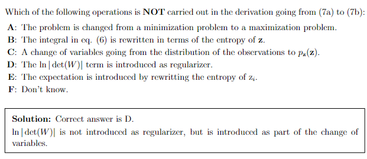

## 22 Problem 4

### 22 4.1

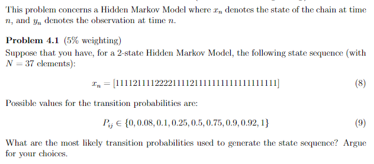

#### Answer

The best estimate we can have is the frequentist point of view, ie. counting the state transitions in chains of each state $1$ and $2$, respectively. This means:

$$\begin{align*} 1 &\rightarrow 1:~~27 ~~|~~ P_{11}=\frac{27}{27+3} = 0.9\\ 1 &\rightarrow 2:~~ 3 ~~|~~ P_{12}=\frac{3}{27+3} = 0.1\\ 2 &\rightarrow 1:~~ 3 ~~|~~ P_{21}=\frac{3}{3+3} = 0.5\\ 2 &\rightarrow 2:~~ 3 ~~|~~ P_{22}=\frac{3}{3+3} = 0.5\\ \end{align*}$$

### 22 4.2

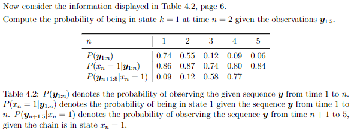

#### Answer

We are asked to compute $P(x_2 = 1|y_{1:5})$. HMM on p. 850 and p. 851 states:

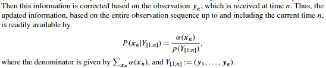

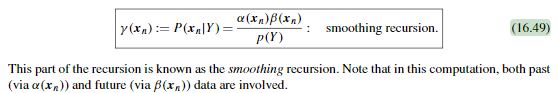

In our problem we have future observations, so we should actually consider the second part with $\beta$! Here $\alpha$ is the past and $\beta$ the future. So, concerning rewriting we use:

$$ \alpha(x_n)= p(y_n|x_n)\sum_{x_{n-1}}\alpha(x_{n-1})P(x_n|x_{n-1}) \\ \beta(x_n)=p(y_{n+1},y_{n+2}, ...,y_N|x_n) = p(y_{n+1:N}|x_n) $$

So:

$$\begin{align*} P(x_n|y_{1:5}) &= \frac{\alpha(x_n)\beta(x_n)}{P(y_{1:N})} \\ &= \frac{\alpha(x_n)P(y_{n+1:N}|x_n)}{P(y_{1:N})} \\ &= \frac{P(x_n|y_{1:n})P(y_{1:n})P(y_{n+1:N}|x_n)}{P(y_{1:N})} \end{align*}$$

Inserting for $n=2$ and $N=5$ $$\begin{align*} P(x_2 = 1|y_{1:5}) &=\frac{P(x_2 = 1|y_{1:2})P(y_{1:2})P(y_{3:5}|x_2 = 1)}{P(y_{1:5})} \\ &= \frac{0.87 \cdot 0.55 \cdot 0.12}{0.06} \\ &= 0.96 \end{align*}$$

Or with Bayes', albeit a bit of the same idea, except one has to split up the probability and do some more rewriting that I find confusing, tbh.

## 22 Problem 5

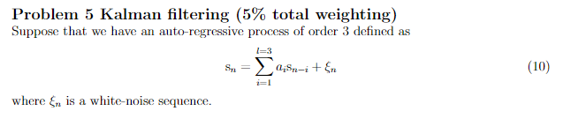

### 22 5.1

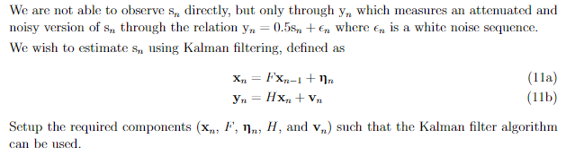

#### Answer

This can be solved using example 4.4 in ML p. 171.

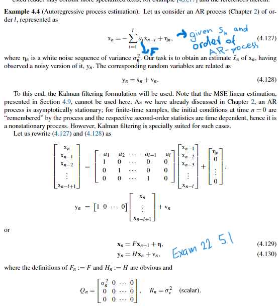

Here we have to recognize that $x_n$ follows the form of (4.127) with slight alterations, one of them being the sign of the sum, and since $\xi_n$ is a white-noise sequence we should recognize the following:

$$ x_n=\begin{bmatrix}s_n \\ s_{n-1} \\ s_{n-2}\end{bmatrix}\\ F = \begin{bmatrix}a_1 & a_2 & a_3 \\ 1 & 0 & 0 \\ 0 & 1 & 0\end{bmatrix} \\ \eta_n = \begin{bmatrix}\xi_n \\ 0 \\ 0\end{bmatrix},~~~~ H = \begin{bmatrix} 0.5 & 0 & 0 \end{bmatrix}, ~~~~ v_n = \epsilon_n $$

## 22 Problem 6

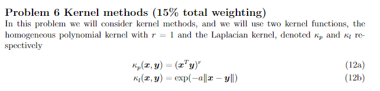

### 22 6.1

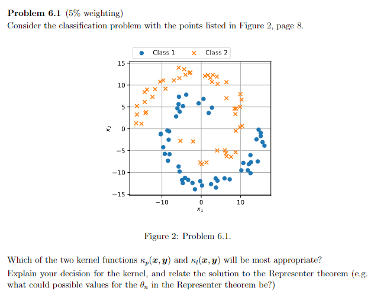

#### Answer

- The Laplacian kernel is better as it measures the distancy between the points, whereas the polynomial kernel with $r=1$ becomes the linear kernel, which is unfit for non-linearly separable data, whereas Laplacian is. Clearly, the data is non-linearly separable.

The representer theorem given in ML (11.17):

$$ f(\cdot) = \sum^N_{n=1}\theta_n\kappa_l(\cdot,x_n), $$ where $x_n$ are the training points, and $\theta_n$ are coefficients determined during training using a test point $x$.

- $\theta_n$ associated with class 1 could be 1, while class 2 could have a -1. Then the decision boundary could be around 0, such that $f(x_{test})>0$ is class 1 and $f(x_{test})<0$ is class 2.

**These images are taken from the solution to aid understanding and would not have been possible to do since we do not have any data of the problem**

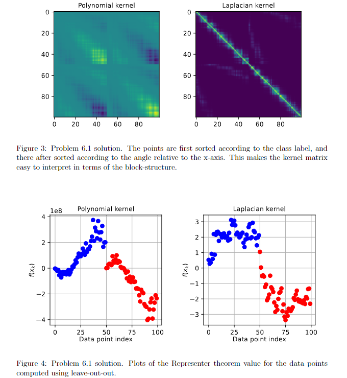

### 22 6.2

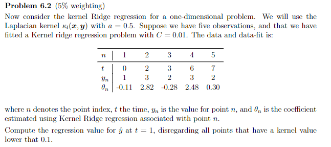

#### Answer

We know that the Laplacian kernel is:

$$ \kappa(x,y)=\exp(-a||x-y||) $$

We are asked for $\hat{y}$ at $t=1$ disregarding points below kernel value of 0.1.

First we need to find the distance between points $x$ and $y$ that would produce a kernel value lower than $0.1$. We start by taking the log:

$$ \ln\kappa(x,y)=-a||x-y|| \\ \Leftrightarrow \\ ||x-y|| = \frac{\ln\kappa(x,y)}{-a} \\ = \frac{\ln{0.1}}{-0.5} $$

```python
xy_dist = np.log(0.1)/(-0.5)
round(xy_dist.item(),2)
```

```
4.61
```

For $t=1$ we can ignore all the points above $t>4.61$ (Solution actually states it is 5.61, but I cannot see why???)

p 553 we have

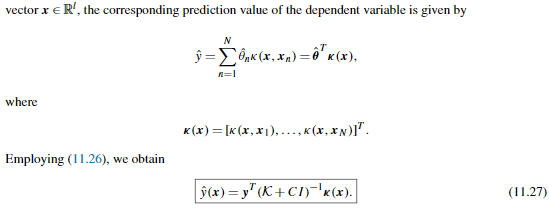

Hence:

$$ \hat{y}=\sum^N_{n=1}\hat{\theta}_n\kappa(x,x_n)=\sum^3_{n=1}\hat{\theta}_n\kappa(t=1,t_{n}), $$ where $x=t=1$ and $x_n=t_{n}$ from the table. Inserting:

```python
a = -0.5
kappa1 = laplacian_kernel(1, 0, a)
kappa2 = laplacian_kernel(1, 2, a)
kappa3 = laplacian_kernel(1, 3, a)
print(f"kappa1 = {round(kappa1,2)}")
print(f"kappa2 = {round(kappa2,2)}")
print(f"kappa3 = {round(kappa3,2)}")
y1 =-0.11*kappa1 + 2.82*kappa2 - 0.28*kappa3
print(f"y1 = {round(y1,2)}")
```

```
kappa1 = 0.61
kappa2 = 0.61
kappa3 = 0.37
y1 = 1.54
```

### 22 6.3

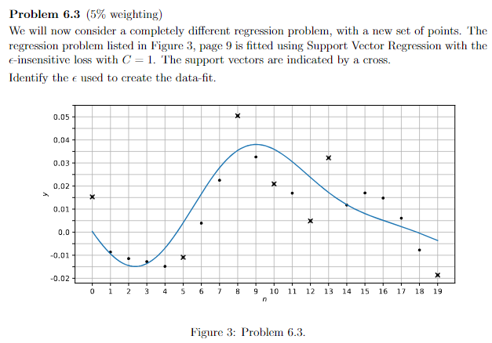

#### Answer

We know that support vectors have to be *on* the epsilon tube or outside its region. Hence, the smallest error between the data fit provided and the support vector would be the $\epsilon$ that has been used. Going through each point, there is no support vector with an error smaller than $0.015$, hence $\epsilon=0.015$.

Another way to look at it is to see which point of the data fit (points) compared to the support vectors (cross-points) has the largest distance from the regression line (blue) and compare it to a support vector with the closest distance.

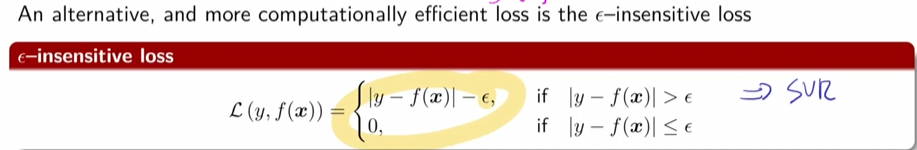

From slide 11 week 13!

# Exam 2023

## 23 Problem 1

### 23 1.1

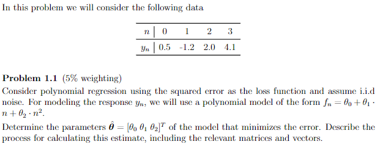

#### Answer

$\theta=(X^TX)^{-1}X^Ty$ where the design matrix is given by

$X=\begin{bmatrix}1 & 0 & 0^2 \\ 1 & 1 & 1^2 \\ 1 & 2 & 2^2 \\ 1 & 3 & 3^2\end{bmatrix}$ and $y=[0.5~~-1.2~~2.0~~4.1]^T$

```python
X = np.array([[1,1,1,1], [0,1,2,3], [0,1,4,9]]).T
y = np.array([0.5, -1.2, 2.0, 4.1])
theta = np.linalg.inv(X.T @ X) @ X.T @ y
print(f"theta = {theta}")
```

```
theta = [ 0.2  -1.45  0.95]
```

### 23 1.2

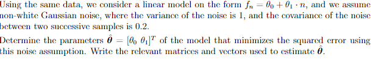

#### Answer

Now we have a linear model assuming non-white Gaussian noise and variance of 1 and covariance of 0.2. Hence, chapter 3.10.1 matches perfectly "Linear regression: The nonwhite gaussian noise case", particularly eq (3.61).

$$ \hat{\theta}_{ML} = (X^T\Sigma_\eta^{-1}X)^{-1}X^T\Sigma_\eta^{-1}y $$

From the information provided we know $\Sigma_\eta$ has to be the same size of the number of observations, ie $4\times4$, where the diagonal is $\sigma_\eta^2=1$ and the two successive samples are given by $0.2$ is the super- and subdiagonal.

Furthermore, we know that $X$ is now only 2 columns given by model $f_n=\theta_0+\theta_1\cdot n$

$$ \Sigma_\eta = \begin{bmatrix} 1 & 0.2 & 0 & 0 \\ 0.2 & 1 & 0.2 & 0 \\ 0 & 0.2 & 1 & 0.2 \\ 0 & 0 & 0.2 & 1 \end{bmatrix} $$ Plugging it in:

```python
Sigma_eta = np.array([[1.0, 0.2, 0.0, 0.0],
                      [0.2, 1.0, 0.2, 0.0],
                      [0.0, 0.2, 1.0, 0.2],
                      [0.0, 0.0, 0.2, 1.0]])
X = np.array([[1, 1, 1, 1],
              [0, 1, 2, 3]]).T
theta_ml = np.linalg.inv((X.T @ np.linalg.inv(Sigma_eta) @ X))@X.T@np.linalg.inv(Sigma_eta)@y
print(f"theta_ml = {theta_ml}")
```

```
theta_ml = [-0.52  1.31]
```

### 23 1.3

General parameter estimation assuming parameter is estimated with 10 different datasets (realizations). For each one we have an unbiased estimator $\hat{\theta}_i$, where the variance of each individual estimator is $\sigma=1$. We aggregate them using:

#### Answer

We CRTL+F'd unbiased estimator, and we see in ML book p 81 and 82 the exact problem definition is described. Here it is described as an average. **Hence, we know the aggregate (or average) estimator is an unbiased estimator and assuming they are mutually uncorrelated and have same variance, ie $\sigma_i=1$ for all $i$**. Then, the variance of the new estimator is much smaller and given by:

$$ \sigma^2_{\hat{\theta}_{agg}}=\mathbb{E}[(\hat{\theta}_{agg}-\theta_o)^2] = \frac{\sigma^2}{N} \\ = \frac{1}{10} = 0.1 $$

## 23 Problem 2

In this problem we consider sparse learning and apply $l_1$ regularization and linear regression (LASSO).

### 23 2.1

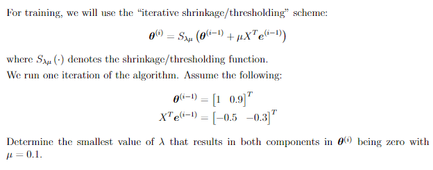

#### Answer

Using the IST (iterative shrinkage and thresholding) algorithm. We must determine the smallest value of $\lambda$ that results in **both** components in $\theta^{(i)}$ being zero with $\mu = 0.1$.

Hence, since $S_{\lambda\mu}(\tilde{\theta})=\text{sign}(\tilde{\theta})\text{max}(|\tilde{\theta}|-\lambda\mu, 0)$, we can rewrite the max() function terms as:

$$ |\tilde{\theta}|-\lambda\mu = 0 \Leftrightarrow \lambda = \frac{|\tilde{\theta}|}{\mu} $$ First, we have to compute what $\tilde{\theta}$ is, given by:

$$ \tilde{\theta}=\theta^{(i-1)}+\mu X^Te^{(i-1)}=\begin{bmatrix}1 \\ 0.9\end{bmatrix}+0.1\cdot\begin{bmatrix}-0.5\\-0.3\end{bmatrix} $$

Inserting into it gives (below), hence $\lambda$ has to be 9.5 and 8.7, respectively, for each parameter to be zero. Hence, for **both** to be zero the smallest value is $\lambda = 9.5$

```python
mu = 0.1
prev_theta = np.array([1, 0.9])
prev_error = np.array([-0.5, -0.3])
theta_tilde = prev_theta + mu * prev_error
print(f"theta_tilde = {theta_tilde}")

l = np.abs(theta_tilde) / mu
print(f"lambda = {l}")
```

```
theta_tilde = [0.95 0.87]
lambda = [9.5 8.7]
```

### 23 2.2

Assume we have chosen $\lambda=1$ and an reliable estimate of the noise of the data is obtained such that $\sigma^2=1$. How does the original regression problem relate to the prior distribution of $\theta$? Determine the parameters of the prior distribution of $\theta$.

#### Answer

We know from exercise 9.1.7 that the LASSO regression is equivalent to the MAP estimate, if using a normal likelihood and a univariate zero-mean Laplace distribution on each weight component in θ.

Furthermore, we also see that if we reparametrize with $b=\frac{2\sigma^2}{\lambda}=\frac{2\cdot 1}{1}=2$ we get the LASSO. So the Laplacian would then be:

$$ p(x|\mu,b=2)=\frac{1}{2b}\exp\bigg(-\frac{|x-\mu|}{b}\bigg) \\ = \frac{1}{2\cdot 2}\exp\bigg(-\frac{|x-\mu|}{2}\bigg) \\ = \frac{1}{4}\exp\bigg(-\frac{|x-\mu|}{2}\bigg) $$

## 23 Problem 3

Echo cancelling setup of a linear FIR filter with $l$ coefficients depicted below:

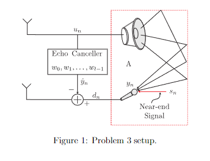

### 23 3.1

Assume we have a signal sequence $u_n$.

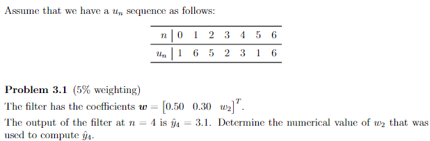

Given the filter coefficients $w$, and that the output of the filter at $n=4$ is $\hat{y}_4=3.1$, determine the numerical value of $w_2$ that was used to compute $\hat{y}_4$

#### Answer

$\hat{y}_n$ is given by the convolution of $u_n$ with the filter weights $w_{0:l-1}$ given by eq (4.41) p 135:

$$ \hat{d}_n = \sum^{l-1}_{i=0}w_iu_{n-i} \\ \Rightarrow \hat{d}_4 = 3.1 = \sum^{3-1}_{i=0}w_iu_4 = w_0u_4+w_1u_3+w_2u_2 \\ = 0.50 \cdot 3 + 0.30 \cdot 2 + w_2 \cdot 5 \\ \Leftrightarrow w_2 = \frac{3.1-(0.5 \cdot 3 + 0.3 \cdot 2)}{5} = 0.2 $$

The filter length $l$ is hidden, but we can find it by observing $w$ only had up to $w_2$ components, ie. $2=l-1 \Leftrightarrow l = 3$ long!

```python
w2 = (3.1-(0.5*3 + 0.3*2)) / 5
print(f"w2 = {w2}")
```

```
w2 = 0.2
```

### 23 3.2

All signals are considered wide-sense stationary stochastic processes (WSS).

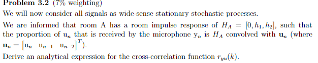

Derive an analytical expression for the cross-correlation function $r_{yu}(k)$.

#### Answer

We are told that $y_n$ is a **room** impulse response $H_A$ convolved with $u_n$ (in addition to the signal!), ie. $y_n=s_n + H_A * u_n$

We know that:

$$\begin{align} r_{yu}(k)&=\mathbb{E}[y_nu_{n-k}] = \mathbb{E}[(s_n+H_A * u_n)(u_{n-k})] \\ &= \mathbb{E}[s_nu_{n-k}+H_A*u_nu_{n-k}] \\ &= \mathbb{E}[s_nu_{n-k}+(\sum^2_{i=0}h_iu_{n-i})u_{n-k}] \\ &= \mathbb{E}[s_nu_{n-k}+h_0u_{n-0}u_{n-k}+h_1u_{n-1}u_{n-k}+h_2u_{n-2}u_{n-k}] \\ &=\mathbb{E}[s_nu_{n-k}+0+h_1u_{n-1}u_{n-k}+h_2u_{n-2}u_{n-k}] \\ &=\mathbb{E}[s_nu_{n-k}]+\mathbb{E}[h_1u_{n-1}u_{n-k}]+\mathbb{E}[h_2u_{n-2}u_{n-k}] \\ &=\mathbb{E}[s_nu_{n-k}]+h_1\mathbb{E}[u_{n-1}u_{n-k}]+h_2\mathbb{E}[u_{n-2}u_{n-k}] \\ &=\mathbb{E}[s_nu_{n-k}]+h_1\mathbb{E}[u_{n}u_{n-(k-1)}]+h_2\mathbb{E}[u_{n}u_{n-(k-2)}] \\ &= r_{su}(k) + h_1\cdot r_u(k-1) + h_2\cdot r_u(k-2) \end{align}$$

Here we have used the definition of convolution (3)-(4), the definition of $h_0=0$ (5), linearity of expectations (6), and moving constants outside the expectation (7), and lastly that it is a WSS signal, hence we can shift freely. Recall we want it on the form $\mathbb{E}[u_nu_{n-(k\pm D)}]$ where $D$ is the displacement in total!

### 23 3.3

We are now given $r_u$ and $r_{du}$ for $k$ of the signal $u_n$ and $d_n$. Now, determine the values of the filter coefficient using a filter length of $l=3$ based on the measurement values.

Additionally, we need a filter with **at most** minimum mean squared error (MMSE) of 0.1! Determine the highest tolerable value of $r_d(0)$. Specify formulas and numerical values!

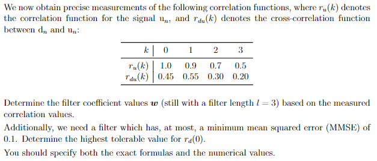

#### Answer

To determine the filter coefficient (with $l=3$) and the MMSE we need to consult the book, particularly p.136 where:

$$R_u=\Sigma_u \\ \Sigma_u w = p \Leftrightarrow w = \Sigma_u^{-1} p = R_u^{-1} p$$

The MMSE can be found in ch. 4.2.1 p. 123 eq. (4.9), where we simply choose the one applicable to our case. In this case $\theta$ is not known, hence we have to use the first option listed here:

$$J(\theta)=\sigma_y^2-p^T\Sigma^{-1}_x p=\sigma^2_y\theta_*^T\Sigma_x\theta_*=\sigma_y^2-p^T\theta_*$$ where $\Sigma_x=\Sigma_u$, as $u$ is our input and $y=d$ is our output, where we recall that the first option $r_d(0)=\sigma_d^2$ of its cross-correlation matrix $\Sigma_d$.

We are informed $J(\theta)=MMSE=0.1$, so we are solving for $\sigma_d^2$:

$$ J(\theta)=0.1=\sigma_y^2-p^T\Sigma^{-1}_x p \\ \Leftrightarrow \\ \sigma_d^2 = r_d(0) = 0.1+p^T\Sigma^{-1}_u p = 0.8 $$

$$ w = \begin{bmatrix}r_u(0) & r_u(1) & r_u(2) \\ r_u(1) & r_u(0) & r_u(1) \\ r_u(2) & r_u(1) & r_u(0)\end{bmatrix}^{-1}\begin{bmatrix}r_{du}(0) \\ r_{du}(1) \\r_{du}(2)\end{bmatrix} = $$

```python
np.set_printoptions(3)
ru0=1.0; ru1=0.9; ru2=0.7; ru3=0.5
rdu0=0.45; rdu1=0.55; rdu2=0.30; rdu3=0.20
R_u = np.array([[ru0, ru1, ru2],
                [ru1, ru0, ru1],
                [ru2, ru1, ru0]])
p = np.array([[rdu0],
              [rdu1],
              [rdu2]])
print(f"R_u = \n{R_u}")
print(f"p = \n{p}")
w = np.linalg.inv(R_u) @ p
print(f"w = \n{w}")

rd0 = 0.1 + p.T @ np.linalg.inv(R_u) @ p
print(f"r_d(0) = {round(rd0.item(), 2)}")
```

```
R_u =
[[1.  0.9 0.7]
 [0.9 1.  0.9]
 [0.7 0.9 1. ]]
p =
[[0.45]
 [0.55]
 [0.3 ]]
w =
[[-1.25]
 [ 3.25]
 [-1.75]]
r_d(0) = 0.8
```

### 23 3.4

We want to choose a step size $\mu$ such that we are sure the filter converges and the weight estimator has **bounded** variance. Determine the maximum value for step-size $\mu$.

#### Answer

To ensure that the filter both **converges** and the weight estimator has a **bounded variance** for a wide-sense stationary signal, we can use the following formula(s) to determine the maximum step size $\mu$.

- p. 200 states that, in a stationary environment (WSS), LMS **converges** to optimal MSE solution in the mean:

$$ 0 < \mu < \frac{2}{\lambda_{\text{max}}} $$

- However, in order for the **variance to be bounded** we must refer to eq. (5.45), where we have to check:

$$ 0 < \mu < \frac{2}{\text{trace}\{\Sigma_x\}} $$

where $\lambda_{\text{max}}$ is the largest eigenvalue of the correlation matrix $R_u$.

Hence we will take the lower of the two, such that it fulfill **both** conditions.

```python
R_u = np.array([[2.0, 1.40, 0.70],
                [1.40, 2.00, 1.40],
                [0.70, 1.40, 2.00]])
eigenvalues = np.linalg.eigvals(R_u)
lambda_max = np.max(eigenvalues)
mu_max = 2 / lambda_max

print(f"Max mu (convergence in LMS): {round(mu_max,2)}")
print(f"Maximum mu (bounded variance): {round(2 / np.trace(R_u),2)}")
```

```
Max mu (convergence in LMS): 0.46
Maximum mu (bounded variance): 0.33
```

### 23 3.5

Assume the time-varying component of the system is adequately modeled:

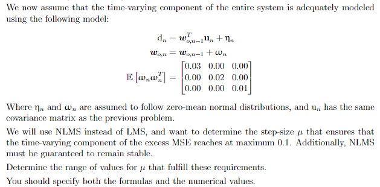

We will use NLMS instead of LMS to determine step-size that ensures the excess MSE reaches at maximum 0.1, and NLMS must be guaranteed to remain stable. Determine a step size that fulfills these requirements.

#### Answer

The formula can be found for the excess MSE in table 6.1 in the ML book p276:

$$ J_{exc}=\frac{1}{2}\mu\sigma_\eta^2\text{trace}\{\Sigma_x\}\mathbb{E}\bigg[\frac{q}{||x||^2}\bigg]+\frac{1}{2}\mu^{-1}\text{trace}\{\Sigma_x\}\text{trace}\{\Sigma_\omega\} $$ where $q=1$ gives the NLMS result.

p. 212 states stability of the NLMS is guaranteed iff. $0<\mu<2$!

The $\text{trace}\{\Sigma_\omega\}$ part is the contributor only time-varying part, so we can look at that specifically.

$$ J_{MSE}^{NLMS}=\frac{1}{2}\mu^{-1}\text{trace}\{\Sigma_x\}\text{trace}\{\Sigma_\omega\} \\ \Leftrightarrow \\ \mu = \frac{1}{2\cdot J_{MSE}^{NLMS}}\text{trace}\{\Sigma_x\}\text{trace}\{\Sigma_\omega\} $$

```python
J_MSE = 0.1
R_u = np.array([[2.0, 1.40, 0.70],
                [1.40, 2.00, 1.40],
                [0.70, 1.40, 2.00]])
R_omega = np.array([[0.03, 0.00, 0.00],
                    [0.00, 0.02, 0.00],
                    [0.00, 0.00, 0.01]])
mu_ = 1 / (2*0.1) * np.trace(R_u) * np.trace(R_omega)
print(f"{round(mu_,2)} < mu < 2")
```

```
1.8 < mu < 2
```

## 23 Problem 4

Concerns ICA with mutual information.

### 23 4.1

Assume we have two sources $s_1$ and $s_2$ which are statistically independent, and two observable variables $x_1$ and $x_2$ defined as:

$$ x_1=s_1+s_2,~~~x_2=s_2 $$ Unmixing the signals using ICA can be done using a unmixing matrix W: $$ \begin{bmatrix} \hat{s}_1 \\ \hat{s}_2 \end{bmatrix} = W \begin{bmatrix} x_1 \\ x_2 \end{bmatrix} $$ Identify W such that $\hat{s}_1$ and $\hat{s}_2$ such that the average mutual information $I(\hat{s}_1, \hat{s}_2 ) = 0$. Show formally that it is true for your solution.

#### Answer

The mixing matrix given $x=As$ can be easily read from the exercise as:

$$A = \begin{bmatrix} 1 & 1 \\ 0 & 1 \end{bmatrix}$$

An obvious choice of unmixing would then be $W=A^{-1}$, since we just move it to the other side by inversion.

The average mutual information is defined for (2.158) and (2.150), however since we are in the continuous case the former is preferred, however since $s_1$ and $s_2$ are statistically independent, it can be seen that $p(s_1, s_2)=p(s_1)p(s_2)$, and this would result in $\ln(1)$ which is $0$, hence the integrand itself goes to 0. So the choice of W does not matter.

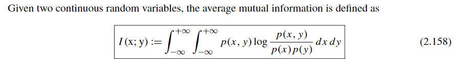

### 23 4.2

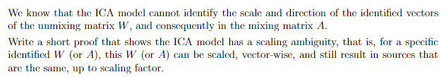

#### Answer

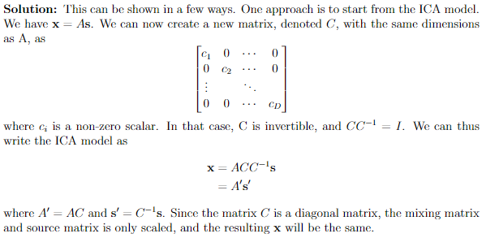

## 23 Problem 5

Hidden Markov Models

### 23 5.1

Suppose a 3-state HMM with initial state probability vector $P_k$ and transition probabilities $P_{ij}$. We will construct a state sequence of length 8 by using sub-sequences of each state A,B,C,D exactly once. Specify the composition that creates the most likely state sequence given the defined HMM and justify your choices.

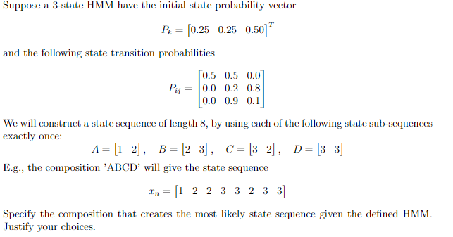

#### Answer

First, we most carefully inspect the $P_k$ and $P_{ij}$. The only way to be in state 1 is to start the chain in state 1! So A is the first sub-sequence (since $P_{21}=0$ and $P_{31}=0$)

When in state 2 or 3, probability of transitioning to other states is higher than staying. Hence, combination of subsequences that change the most is the goal.

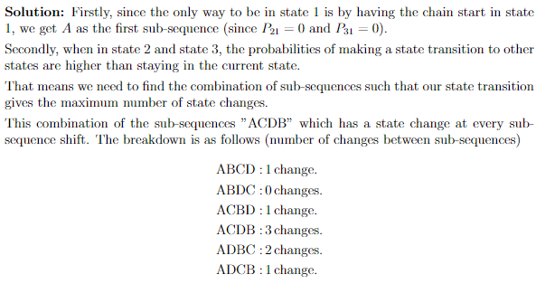

### 23 5.2

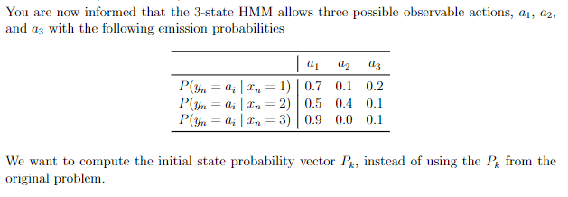

Based on the observations you know that $P(y_1=a_1)=0.68$ and $P(y_1=a_2)=0.15$.

Compute the initial state probability vector $P_k$ given this information.

#### Answer

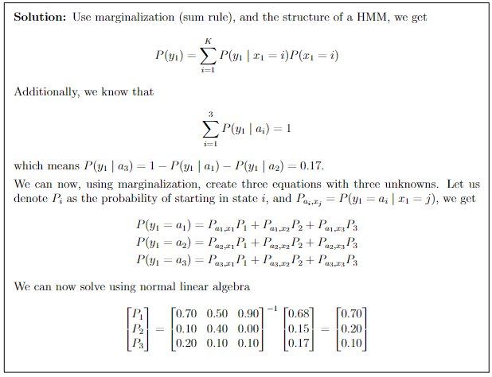

## 23 Problem 6

Kalman filtering

### 23 6.1

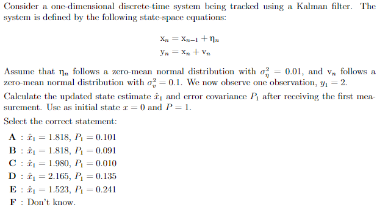

#### Answer

p 169 has algorithm 4.2 the Kalman Filtering algorithm. We must calculate after correction, ie. $\hat{x}_{n|n}$ and $P_{n|n}$ is our goal.

Let's denote what we know from the problem, ie.

- $R_n=\sigma_v^2=0.1$
- $H_n=1$
- $F_n=1$
- $P_{n|n-1}=P_{1|0}=1$
- $y_n=y_1=2$
- $\hat{x}_{n|n-1}=x_0=0$

Using the algorithm:

$$\begin{align*} S_n &= R_n + H_nP_{n|n-1}H_n^T = 0.1 + 1\cdot 1\cdot 1 = 1.1 \\ K_n &= P_{n|n-1}H_n^TS_n^{-1} = 1\cdot 1 \cdot 1.1^{-1} = \frac{1}{1.1} = 0.909 \\ \hat{x}_{n|n} &= \hat{x}_{n|n-1}+K_n(y_n-H_n\hat{x}_{n|n-1}) = 0 + 0.909\cdot (2-1\cdot 0) = 1.818 \\ P_{n|n} &= P_{n|n-1} - K_nH_nP_{n|n-1} = 1 - 0.909 \cdot 1 \cdot 1 = 0.091 \end{align*}$$

So correct is B.

## 23 Problem 7

Kernel methods

### 23 7.1

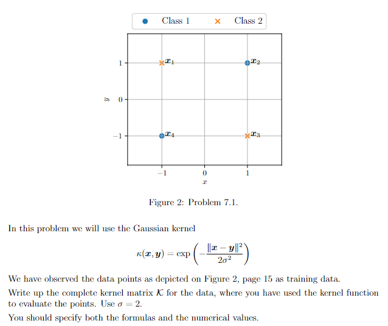

#### Answer

We use

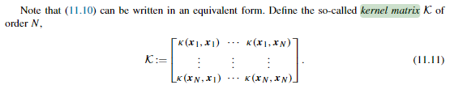

```python
K = np.zeros((4,4)) # placeholder
# Problem definitions
sigma = 2
x1 = np.array([-1,1])
x2 = np.array([1,1])
x3 = np.array([1,-1])
x4 = np.array([-1,-1])
all_x = [x1, x2, x3, x4]
for i in range(K.shape[0]):
    for j in range(K.shape[1]):
        K[i,j] = np.exp(-np.linalg.norm(all_x[i] - all_x[j])**2 / (2*sigma**2))
print(f"K = \n{K}")
```

```
K =
[[1.    0.607 0.368 0.607]
 [0.607 1.    0.607 0.368]
 [0.368 0.607 1.    0.607]
 [0.607 0.368 0.607 1.   ]]
```

### 23 7.2

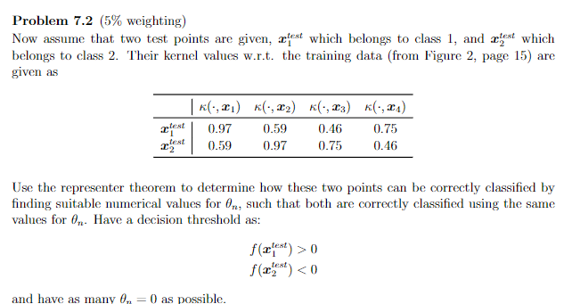

#### Answer

The representer theorem given in ML (11.17):

$$ f(\cdot) = \sum^N_{n=1}\theta_n\kappa_l(\cdot,x_n), $$ where $x_n$ are the training points, and $\theta_n$ are coefficients determined during training using a test point $x$.

Most times I've seen a decision boundary around 0 it corresponds to at least 2 different $\theta$'s which have values $\theta_1=1$ and $\theta_2=-1$, respectively for each class. This would give "opposite" signs for each test point $x_n^{test}$, so let's try and see if that's enough and we can set the rest to $\theta_n=0$.

$$ f(x_1^{test})=\theta_1\kappa(\cdot,x_1)+\theta_2\kappa(\cdot,x_2)=1\cdot 0.97 + (-1)\cdot 0.59 = 0.38 \\ f(x_2^{test})=\theta_1\kappa(\cdot,x_1)+\theta_2\kappa(\cdot,x_2)=1\cdot 0.59 + (-1)\cdot 0.97 = -0.38 $$ Hence, for $f(x)>0$ gives class 1 and $f(x)<0$ gives class two, which satisfies the decision threshold!

### 23 7.3

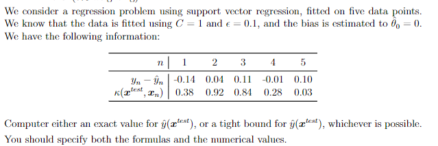

#### Answer

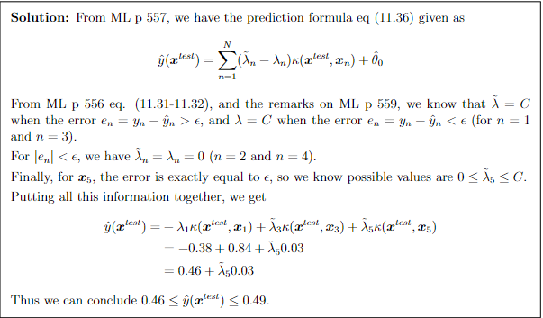